# Economía Política

Unidad 8. I love the smell of napalm in the morning. Conflicto, violencia política y consecuencias sociales y políticas

Sebastian Freille

Universidad Nacional de Córdoba

> War is the continuation of politics by other means.  
> **[Carl von Clausewitz (1832)]**

# **La guerra es la excepción no la regla**

- Hechos estilizados
- Conflicto civil interno
- Teorías de conflicto (armado)
- Recursos naturales y conflicto civil
  - *Resource curse*

## Hechos estilizados

[figure not shown]

Cantidad absoluta de muertes en gradual declive desde 1945

## Hechos estilizados (cont.)

[figure not shown]

También han bajado en terminos relativos a la población

## Hechos estilizados (cont.)

[figure not shown]

Pero ha aumentado el número de conflictos de menor mortalidad

## Naturaleza de conflictos (cont.)

- No sólo es común el conflicto, sino también *persistente*. Alrededor de un 20% de los países han experimentado al menos 10 años de guerra civil desde 1960
- La proporción de países involucrados en conflictos civiles incrementó para tener un pico en los 1990s para luego bajar a mediados de los 2000s
- La pregunta surgió naturalmente ¿por qué tantos conflictos?
  - Una respuesta obvia $\longrightarrow$ pobreza. Después de todo, la evidencia sugiere que la correlación es muy robusta

## Naturaleza de conflictos (cont.)

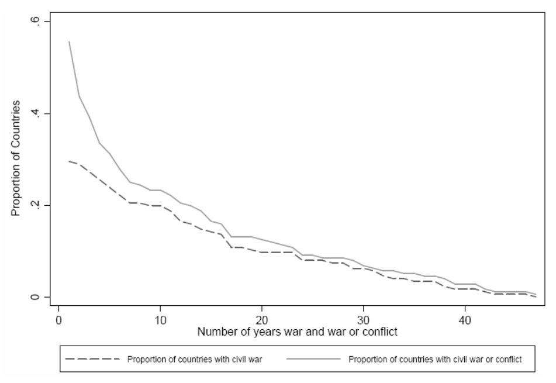

Persistencia de los conflictos

## Naturaleza de conflictos (cont.)

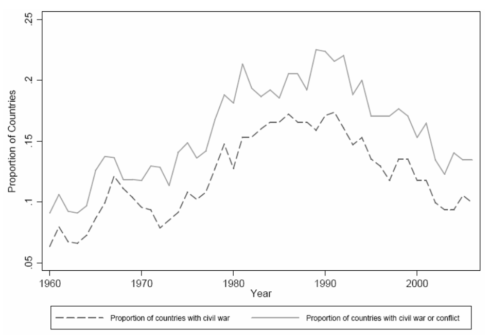

Aumento de los conflictos

## Naturaleza de conflictos (cont.)

[figure not shown]

Conflictos y PIB per cápita

## Problema de sesgos

- El hecho es que aún los peores enemigos prefieren odiarse en paz –medios, libros e historia focalizan en los *eventos ocurridos*.
  - No hay libros sobre *eventos evitados*.
- En Africa, se ha registado 1 (un) caso principal de violencia étnica por año dentro de un total potencial de 2000.
- En India, menos de 1 (un) disturbio cada 10 millones de personas por año y tasas de mortalidad de 16 cada 10 millones
- Guerras y conflictos son eventos mas *salient*

## Problema de segos (cont.)

- Foco en las fallas es un ejemplo de sesgo de selección $\longrightarrow$ dos consecuencias importantes
  - Exageramos la frecuencia e intensidad del conflicto
  - Confundimos las raíces de la guerra y los senderos hacia la paz
- Ilustración $\longrightarrow$ causas comunmente citadas al fracasar la paz líderes fallidos, pobreza extrema, injusticias históricas, armas baratas y así.
- Pero esto *ignora la cantidad de veces que el conflicto fue evitado* y existían, sin embargo, las mismas condiciones.

## Problema de segos (cont.)

[figure not shown]

Sesgo del sobreviviente

## Problema de segos (cont.)

> **Sesgo del sobreviviente.** Cuando los aviones norteamericanos regresaron de misiones sobre posiciones alemanas en la 2GM, estaban llenos de agujeros de bala sobre el cuerpo y las alas del avión. El ejército de EEUU encargó a sus ingenieros añadir más protección a estas partes. Un estadístico llamado Abraham Wald estuvo en desacuerdo y dijo que los ingenieros debían hacer exactamente lo opuesto: proteger los motores y la cabina donde los aviones retornados estaban intactos. Había deducido algo clave: los agujeros faltantes debían estar en los aviones faltantes. Las balas a los motores y la cabina hacían caer a los aviones. El ejército erroneamente se enfocaba en una muestra sesgada y por lo tanto identificaba causas erróneas del fenómeno.

## Problema de segos (cont.)

- Cuando hablamos de conflicto, cometemos un error similar pero opuesto $\longrightarrow$ nos enfocamos mucho en las veces que la paz falla [mirar sólo los aviones caídos!]
- Estos eventos muestran que analizando los que “cayeron” sólo cuenta parte de la historia y muchas veces de manera confusa –de las cientos de balas que tenían los aviones caídos ¿cuál/es fueron las determinantes de la caída?
- Para encontrar las raíces de la guerra y la violencia, debemos analizar los conflictos que se mantienen pacíficos

## Conflictos políticos

- Un tipo de conflicto muy relevant es el *conflicto político*. El Heidelberg Institute for International Conflict Research (HIIK) elabora desde hace 30 años el Conflict Barometer
- No focalizan en víctimas sino en cantidad de conflictos y su naturaleza
- Distinguen 5 (cinco) tipos de conflicto según su intensidad
  1. Disputa
  2. Crisis no violenta
  3. Crisis violenta
  4. Guerra limitada
  5. Guerra

## Conflictos políticos (cont.)

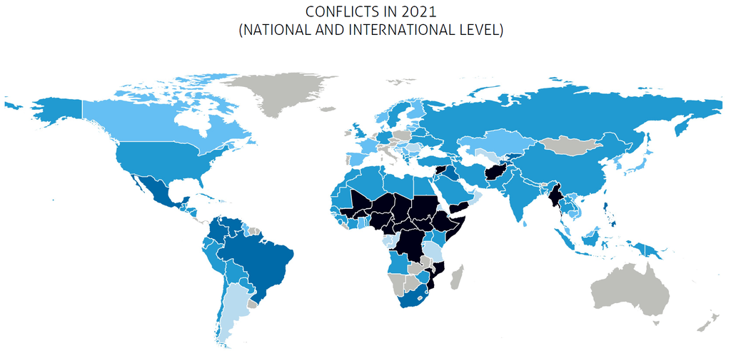

Todos los conflictos - Nivel nacional

## Conflictos políticos (cont.)

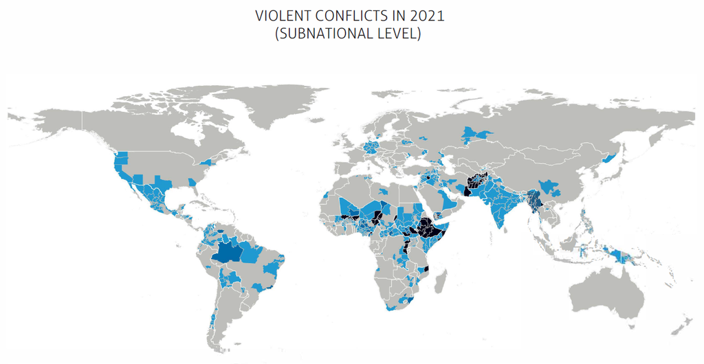

Conflictos violentos - Nivel subnacional

# **Incentivos para la paz y la guerra**

## Ejemplo e ilustración (cont.)

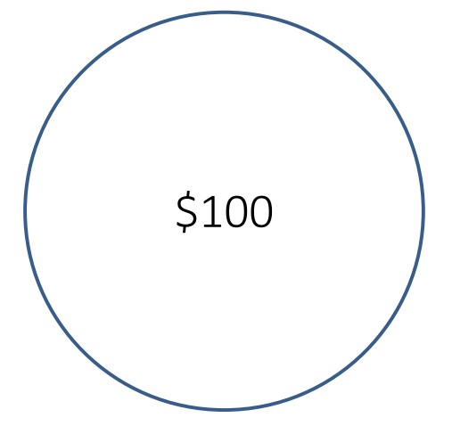

(a) El mundo Griego

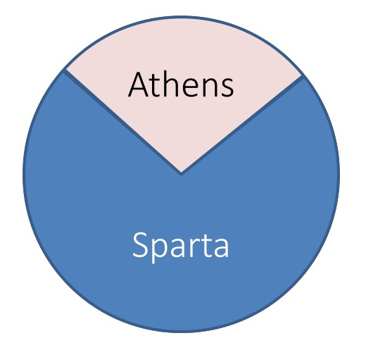

(b) Control de las partes

Figura 1: El mundo Griego: paz y guerra

## Ejemplo e ilustración (cont.)

- Supongamos que Esparta tiene una probabilidad de 0.75 de ganar la guerra, $p=0.75$. Atenas conoce perfectamente el poderío de Esparta y conoce que su probabilidad de ganar es de sólo 0.25, $1-p=0.25$
- En estas condiciones, la utilidad esperada de cada bando son:
  - Esparta: [$400*(0.75)-C*(0.75)]+[$0*(0.25)-C*(0.25)]=300-C
  - Atenas: [$0*(0.75)-C*(0.75)]+[$400*(0.25)-C*(0.25)]=100-C
- ¿Qué pasa si el costo de la guerra, $C$ es igual a 90? ¿Preferirán la guerra al *status-quo*? ¿Uno o ambos?

## Ejemplo e ilustración (cont.)

[figure not shown]

Utilidad esperada de la guerra: Esparta y Atenas

## Ejemplo e ilustración (cont.)

- Nóteses que *la guerra es ineficiente*
  - La distribución inicial $250/$150 era estable –aún si desigual
    - con la guerra con un costo alto la distribución es $210/$10 –*lose-lose*
- Habra pues una **zona de negociación**
- La division final dependerá de las reglas y del que mueve primero

## Ejemplo e ilustración (cont.)

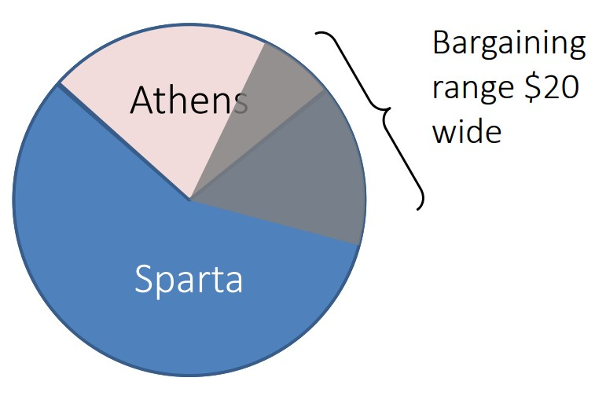

La solucion negociadas

## Ejemplo e ilustración (cont.)

- Suponga ahora que con los mismos valores y $C=30$ pero debido a una purga de militares se debilita su poder y ahora $p=0.25$.
  - ¿esperaría usted que haya guerra o negociación? ¿Cuál sería la zona de negociación en caso de que existiera?
- Ahora Atenas va a tener un incentivo a iniciar la guerra –puede pasar de $150 a $270! En este caso será Esparta quien tenga el incentivo a realizar una oferta (transferencia) para evitar la guerra
  - esta transferencia deberá ser entre $120 y $180

# **Razones del conflicto**

## Relación entre conflictos y grado de desarrollo

- Problema de causalidad reversa $\longrightarrow$ guerras destruyen recursos (físicos, humanos), empeoran las condiciones sanitarias y los estándares de vida
  - Ejemplo escalofriante $\longrightarrow$ República Democrática de Congo donde millones murieron *indirectamente* de hambre y/o enfermedad
- Esto afecta la economía. Además: aumenta emigración, surgen mercados paralelos, y peligran instituciones políticas
- Pero también hay otra paradoja $\longrightarrow$ la guerra ha sido vinculada con el desarrollo de innovaciones tecnológicas e institucionales detrás del edesarrollo de algunas potencias europeas

## ¿Por que peleamos?

- Blattman (2022) en un muy importante libro lista 5 (cinco) razones que motivan las guerras (y el conflicto en general):
  1. Intereses no controlados
  2. Incentivos intangibles
  3. Incertidumbre
  4. Problema del compromiso
  5. Percepciones erróneas

## Intereses no controlados

- Si los que deciden la guerra pueden ignorar (parcial o totalmente) los costos de la guerra, entonces irán a la guerra frecuentemente
- En ocasiones por ganancia personal a través del conflicto –sea económica, política
- Líderes sin control político han sido uno de los grandes *drivers* de guerras en la historia

## Incentivos intangibles

- En ocasiones, la violencia se entiende a partir de ganar algo valorado –venganza, status, dominación.
- Otros casos vinculados con doctrinas y religiones –si es así, los costos de la guerra son (para estos grupos) infimos en comparación con el objetivo último

## Incertidumbre

- Una razón por las cuales las soluciones de negociación o compromiso fracasan es por la incertidumbre.
- La idea básica es que las partes desconocen las cartas del otro pero saben que tienen un incentivo a engañarlo [Tip: lógica del dilema del prisionero]
- No siempre ante la amenaza uno se va al mazo y en ocasiones terminás entrando –a veces suele ser la mejor estrategia

## Problema del compromiso

- Sucede cuando una parte puede advertir el crecimiento de poder de la otra y tiene un fuerte incentivo a atacar antes de que sea demasiado tarde
- ¿Podría la otra parte amenazante acaso proponer algo a la parte en el poder *creíblemente* para que no lo ataque?
  - Nuevamente el problema de *hold-up*
- Ambos prefieren la negociación pero ninguno puede ofrecer un acuerdo creíble

## Percepciones erróneas

- Personas son *overconfident* por naturaleza. Suponemos que la otra parte piensa como nosotros, valora las mismas cosas y ven el mundo de la misma forma.
- Se demoniza a los enemigos y le atribuimos los peores motivos
- De este modo, nos aferramos a creencias erróneas y esto limita nuestra capacidad de articular un acuerdo posible

# **Teorías de conflicto (armado)**

## Teorías tradicionales

- Fearon sugiere 3 (tres) motivos por los que podría haber conflicto
  1. Líderes (sociedades) son *irracionales* –impulsos barbáricos, megalomanía, *overconfidence*
  2. Líderes (sociedades) son racionales pero no internalizan los costos de la guerra
  3. Líderes (sociedades) son racionales e internalizan los costos de la guerra pero aún así hacen guerra en ciertas circunstancias
  - Cuando hay información asimétrica
  - Cuando hay un problema de compromiso

## El caso de Liberia

- Liberia tenía un régimen constitucional entre 1847 y 1980 pero con supresión de voto a indígenas. En 1980, Samuel Doe encabezó un guerrilla, instaló un gobierno dictatorial y centraliza la política y libera la economía
- Cuenta con apoyo (y ayuda) de EEUU que pierde al finalizar la guerra fría. Régimen brutal y represivo
- En 1989 otro militar formado en EEUU, Charles Taylor, aprovecha la caída del comunismo y que EEUU le “suelta la mano” a Doe, y marcha sobre Liberia junto a Johnson. En 1989 comienza la primera guerra civil liberiana (1989-1997); luego se produce la segunda guerra civil liberiana (1999-2003).

## El caso de Liberia (cont.)

[figure not shown]

Las guerras civiles de Liberia

## El caso de Liberia (cont.)

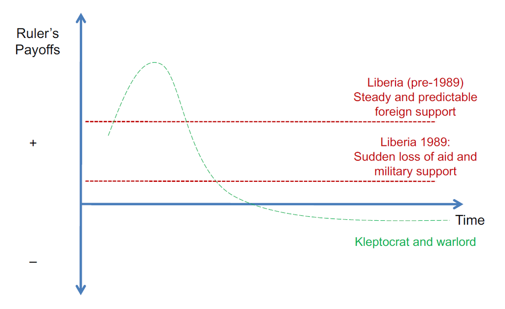

Los contextos y oportunidades de los líderes

## El caso de Liberia (cont.)

- Tanto Doe como Taylor muy posiblemente pudieron ignorar completamente los costos sociales del conflicto.
- Sumando la caída del apoyo y ayuda luego de la guerra fría y adicionalmente a los mínimos castigos por los crímenes de guerra, incentivaba aún más el modelo dictatorial
- Con el tiempo, empezaron las presiones por la liberalización y democratización del continente

## El caso de Liberia (cont.)

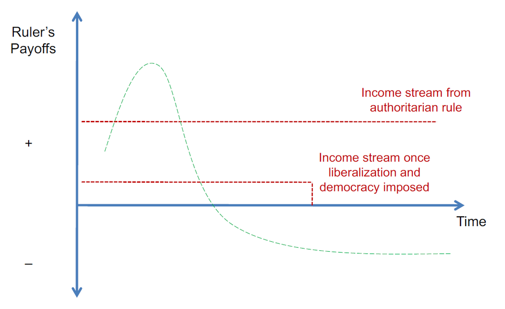

Los contextos y oportunidades de los líderes

## Recursos naturales y conflicto civil

- Algunos recursos naturales son más “saqueables” que otros
  - Recursos minerales de alto valor, altamente concentrados (oro, diamantes, petróleo)
  - Recursos naturales agrarios, pesqueros, etc.

## Recursos naturales (cont.)

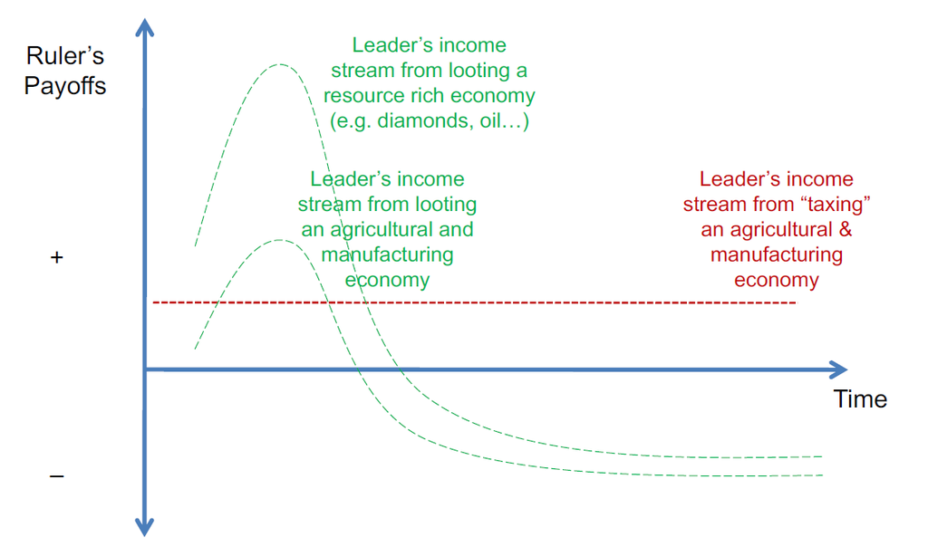

Tipos de recursos y rentas del saqueo

## La violencia es ineficiente

- El *puzzle* de Fearon
  - Luchar es costoso
  - Cualquier escenario de paz es mejor para todas las partes que los escenarios que siguen a una guerra
  - Existe una solución negociada que es mejor para todas las partes
  - Actores racionales y perfectamente informados no deberían luchar (a menos que no internalicen los costos)

## La violencia es ineficiente (cont.)

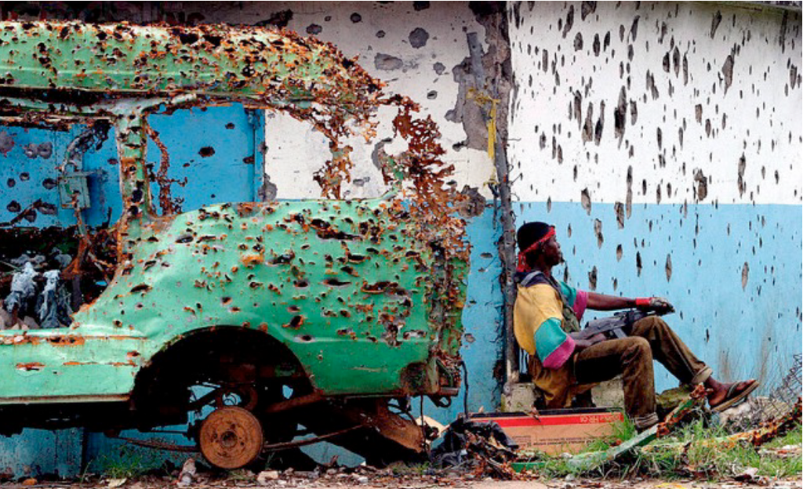

Cicatrices de la violencia en Liberia

## ¿Por qué Taylor invadió Liberia?

- Irracionalidad (*overconfidence*, megalomano)? No muy plausible
- Falló en internalizar costos? Altamente plausible
- ¿Asimetrías de información? ¿Problemas de compromiso?
  - Posible existencia de ambas

## ¿Por qué Taylor invadió Liberia? (cont.)

- Asimetrías de información
  - Lider actual (Doe) no conocía la fuerza del desafiante rebelde (Taylor)
    - Muy posible: insurgentes incentivo a ser secretos
  - No instituciones para comunicación y dialogo
    - Domesticas $\longrightarrow$ destruidas intencionalmente
    - Internacionales $\longrightarrow$ en caos por caída bloque
  - Pobre estimación de longitud y profundidad del conflicto –dos guerras civiles devastadoras surgieron de aqui

## ¿Por qué Taylor invadió Liberia? (cont.)

- Problemas de compromiso
  - Poder altamente centralizado en Liberia
    - Compromiso no creíble de compartir poder (lider actual)
    - Compromiso no creíble de seguir compartiendo producido del saqueo (lider insurgente)
  - Cese de la ayuda internacional debilita al regimen
  - Oportunidad de reducir *permanentemente* el poder del grupo opositor
    - “Limpieza étnica”

## ¿Por qué Taylor invadió Liberia? (cont.)

- ¿Qué se puede hacer? Instituciones de resolución de conflictos pueden ayudar pero en estados débiles
  - Instituciones informales son débiles
    - Superposición de autoridades y normas
    - Normas tradicionales pueden ser injustas
  - Instituciones formales funcionan pobremente
    - Cortes civiles y criminales corruptas
    - Policía no entrenada y corrupta
    - Reglas legales y leyes inciertas, poco claras

## Modelos de contienda

- Teorías de conflicto armado se distancian de supuestos tradicionales
  - derechos de propiedad no definidos/protegidos
  - contratos entre partes no pueden ser *enforced*
  - líderes pueden ser reemplazados por canales no institucionales (elecciones)
- Modelo básico [Haavelmo (1954), Hirschleifer (1988, 1989)] asume 2 (dos) partidos, 1 (un) grupo rebelde y 1 (un) gobierno.
  - Decisión $\longrightarrow$ asignación entre 2 actividades –*producción* o *apropiación*.

## Modelos de contienda (cont.)

- Apropiación modelada como una función de éxito de la competencia –insumos (armas) se traducen en probabilidad de ganar del bando 1, $p_{1}$ y por ende consumir la producción del bando $p_{2}$ además de la propia
  $$\begin{align}
  p_{1}(G_{1},G_{2})=\frac{G_{1}^{m}}{G_{1}^{m}+G_{2}^{m}}
  \end{align}$$
- donde $G_{1}$ y $G_{2}$ son las armas del grupo 1 y 2 respectivamente y $m$ captura la efectividad del armamento en determinar al vencedor
- Modelos de contienda $\longrightarrow$ la probabilidad de ganar aumenta con la efectividad relativa de la tecnología de lucha
  - Tecnología de lucha $\longrightarrow$ acceso a armas de fuego, líderes astutos, *inteligencia* y otros

## Modelos de contienda (cont.)

- Grossman (1991) contempla actores no unitarios (problema de coordinación) $\longrightarrow$ condición de incentivo a participar
  - Los lideres deben incentivar a los individuos a unirse –participación aumenta a menor costo de oportunidad de luchar (pobreza)
- Dal Bo and Dal Bo (2004) predicen aumento del riesgo de conflicto ante shocks de ingreso al sector intensivo en $K$ y disminución del riesgo ante shocks al setor intensivo en L
- Besley and Person (2008) $\longrightarrow$ volatilidad de TIE estimular el conflicto armado
  - Aumentos en $P_{m}$ lo hacen via baja del salario real
  - Aumentos en $P_{x}$ lo hacen via aumento de la torta de recursos del gobierno

## Información asimétrica y contratos incompletos

- Modelo de contienda $\longrightarrow$ armarse y pelear ocurre siempre en el equilibrio
  - En otras palabras *no hay decisión de pelear* –armarse y pelear se implican mutuamente
- Esto no es muy realista $\longrightarrow$ competencia política por el poder y los recursos siempre presente pero no así el conflicto

## Información asimétrica y contratos incompletos (cont.)

- Mas relevante: estudiar los determinantes del compromiso (y su ausencia)
- ¿Por qué existen las guerras?
  - Si grupos en pugna son *racionales* ambos deberían preferir una solución negociada
- Literatura:
  - Acemoglu and Robinson (2001; 2006) $\longrightarrow$ elites y clases pobres, amenaza de revolución
  - Boix (2003) $\longrightarrow$ aparición de conflicto de la mano de shocks en la capacidad militar de un desafiante revolucionario

## Información asimétrica y contratos incompletos (cont.)

- Fearon (1995) brinda 3 (tres) razones por las cuales la negociación puede fallar:
  1. Los líderes no siempre se comportan racionalmente
  2. Los líderes pueden ser totalmente racionales pero no internalizar los costos del conflicto por problemas de agencia política
  3. Los líderes pueden ser totalmente racionales e internalizar los costos del conflicto completamente pero sin embargo ven la guerra como inevitable

## Información asimétrica y contratos incompletos (cont.)

- Asimismo señala 3 (tres) mecanismos consistentes con el argumento de “*guerra racional*”
  1. Información asimétrica $\longrightarrow$ información privada sobre el poderío militar y el incentivo estratégico de “ningunear” potenciales oponentes
  2. Problemas de compromiso $\longrightarrow$ incapacidad de las partes de comprometerse a pactos en ausencia de un *enforcer* externo
  3. Indisivilidades $\longrightarrow$ algunos temas/issues simplemente no admiten compromiso y negociación –ie soberanía Malvinas

## I - Información asimétrica

- Guerra puede ocurrir cuando se sobreestima (capacidad de ganar) y/o subestima (capacidad de ganar del rival)}
  - Incentivo a falsificar verdadera fuerza para lograr disuadir a potenciales futuros oponentes [el régimen de Saddam Hussein y su exageración sobre el stock de WOMD
- En modelos con más de 2 (dos) jugadores, toma de decisiones colectivas Pareto-optimas es imposible y el conflicto surge siempre.

## II - Problema del compromiso y contratos incompletos

- Casos mas interesantes donde aún con informacion perfecta, es inevitable el conflicto debido a un problema de compromiso –al menos una parte tiene incentivo a no cooperar una vez que se llega al acuerdo
- Powell (2006) muestra que estos problemas de compromiso tienen la base en un único fenomeno: grandes desplazamientos en la futura distribución de poder
- Ejemplo $\longrightarrow$ un gobierno *coyunturalmente* débil intenta comprar a un grupo rebelde con transferencias para lograr la paz. Cuando recobra fortaleza, estará motivado a renegar de su compromiso. Esto limita lo que está dispuesto a ofrecer hoy a los rebeldes y estos inician guerra con payoff mayor.

## II - Problema del compromiso y contratos incompletos (cont.)

- Ejemplo II $\longrightarrow$ de la misma manera surge un problema de compromiso cuando una parte puede alterar *permanentemente* el balance de poder recurriendo a la guerra hoy. Si ir a la guerra debilita o incluso elimina a un grupo rebelde para siempre, entonces al estado le convendrá hacer una guerra sangrienta pero corta si los acuerdos de paz no son creíbles